# Question

Considere o seguinte gráfico de barras para a variável quantitativa discreta *número de vendas por dia* de uma determinada companhia:

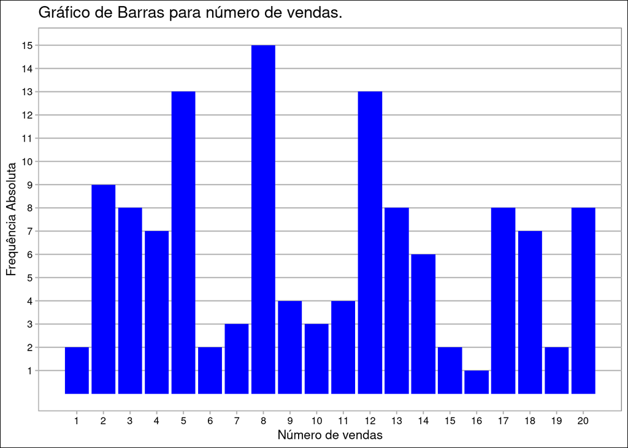

A partir do gráfico acima, preencha os espaços vazios na tabela de distribuição de frequência para a variável *número de venda por dia*:

[output not shown]

# Solution

| Número de vendas | Frequência | Porcentagem |
| --- | --- | --- |
| 1 | 2 | 1,6 |
| 2 | 9 | 7,2 |
| 3 | 8 | 6,4 |
| 4 | 7 | 5,6 |
| 5 | 13 | 10,4 |
| 6 | 2 | 1,6 |
| 7 | 3 | 2,4 |
| 8 | 15 | 12 |
| 9 | 4 | 3,2 |
| 10 | 3 | 2,4 |
| 11 | 4 | 3,2 |
| 12 | 13 | 10,4 |
| 13 | 8 | 6,4 |
| 14 | 6 | 4,8 |
| 15 | 2 | 1,6 |
| 16 | 1 | 0,8 |
| 17 | 8 | 6,4 |
| 18 | 7 | 5,6 |
| 19 | 2 | 1,6 |
| 20 | 8 | 6,4 |

# Meta-information